# Praktikum 2-Autokorelasi

## Pemanggilan *Packages*

```r
library(dplyr)
library(TTR)
library(forecast)
library(lmtest) #digunakan untuk uji formal pendeteksian autokorelasi
library(zoo)
library(orcutt) #untuk membuat model regresi Cochrane-Orcutt
library(HoRM) #untuk membuat model regresi Hildreth-Lu
library(rio)
```

## Input Data

Data yang digunakan dalam kesempatan kali ini adalah data Air Quality New Delhi yang berjumlah 72 baris.

```r
newdelhi <- import('https://raw.githubusercontent.com/AngelMartha/PraktikumMPDW/main/P2/New%20Delhi%20AQI.csv')
View (newdelhi)
```

### Cleaning Data

```r
### menghapus kolom yang tidak diperlukan
newdelhi = newdelhi[,-c(1,4,10,11,12)]
```

## Eksplorasi Data

### Mencari peubah x yang berpengaruh terhadap y

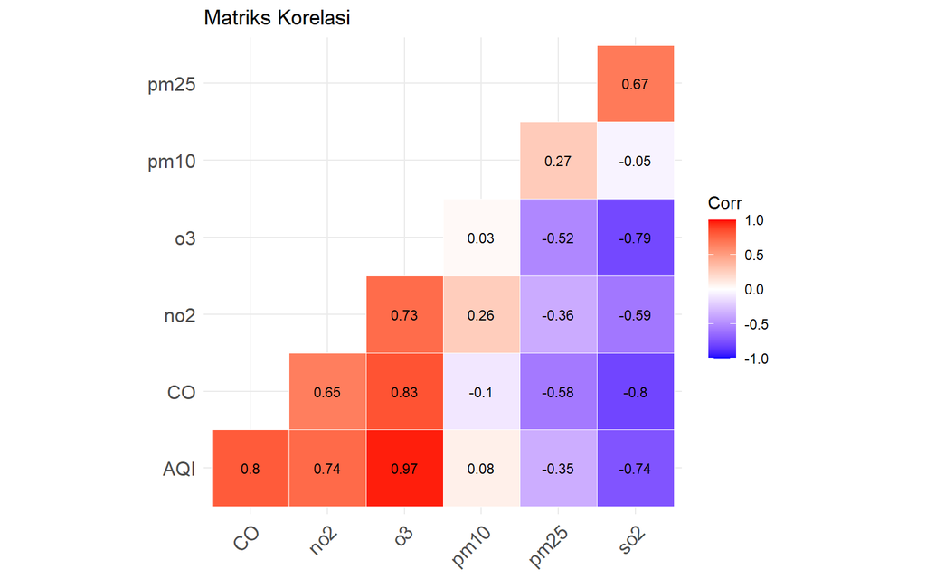

```r
library(ggplot2)
library(ggcorrplot)
cor_matrix <- cor(newdelhi)
matriks_korelasi <- ggcorrplot(
                        cor_matrix,
                        type = "lower",  # Menampilkan separuh bawah matriks saja
                        lab = TRUE,       # Menampilkan label berapanya di setiap sel
                        lab_size = 3,     # Ukuran font untuk label
                        colors = c("blue", "white", "red"),
                        outline.color = "white", # Warna garis tepi
                        title = "Matriks Korelasi" # Judul plot
)
matriks_korelasi
```

Hasil dari matriks korelasi yang telah dibuat untuk melihat peubah yang berpengaruhterhadap AQI: 1. Peubah CO, no2, O3, dan pm10 memiliki korelasi positif 2. Peubah pm25 dan so2 memiliki korelasi negatif 3. Peubah CO dan O3 memiliki hubungan korelasi paling kuat diantara peubah lainnya

Sebelum melakukan regresi, akan diperlihatkan *plot time-series* dari ndeks Air Quality Kota New Delhi.

```r
#Membentuk objek time series
data.ts<-ts(newdelhi$AQI)
data.ts
```

```
## Time Series:
## Start = 1
## End = 72
## Frequency = 1
##  [1] 30.2 28.2 26.6 25.0 26.0 26.0 26.0 24.0 23.0 24.0 25.0 26.0 27.0 29.0 29.0
## [16] 29.0 29.0 28.0 27.0 27.0 27.0 27.0 27.0 27.0 27.0 28.0 29.0 31.0 31.0 32.0
## [31] 32.0 31.0 31.0 30.0 30.0 29.0 27.0 26.0 25.0 25.0 24.0 24.0 25.0 25.0 25.0
## [46] 26.0 26.0 27.0 27.0 27.0 27.0 28.0 28.0 27.0 27.0 26.0 25.0 23.0 22.0 21.0
## [61] 20.0 19.0 19.0 20.0 21.0 21.0 21.0 22.0 24.0 26.0 27.0 28.0
```

[figure not shown]

```r
#Membuat plot time series
ts.plot(data.ts, xlab="Time Period ", ylab="IPM", main= "Time Series Plot of Repsol")
points(data.ts)
```

## Regresi

Setelah mengetahui adanya hubungan antar dua peubah, maka model regresi dapat ditentukan.

```r
#Pembuatan Model Regresi
#model regresi
model<- lm(AQI~o3+CO, data = newdelhi)
summary(model)
```

```
##
## Call:
## lm(formula = AQI ~ o3 + CO, data = newdelhi)
##
## Residuals:
##     Min      1Q  Median      3Q     Max
## -0.5528 -0.3667 -0.1130  0.1647  4.3592
##
## Coefficients:
##             Estimate Std. Error t value Pr(>|t|)
## (Intercept)  3.52239    5.59265   0.630    0.531
## o3           0.47460    0.02328  20.384   <2e-16 ***
## CO          -0.02094    0.03316  -0.632    0.530
## ---
## Signif. codes:  0 '***' 0.001 '**' 0.01 '*' 0.05 '.' 0.1 ' ' 1
##
## Residual standard error: 0.7053 on 69 degrees of freedom
## Multiple R-squared:  0.9482, Adjusted R-squared:  0.9467
## F-statistic: 631.5 on 2 and 69 DF,  p-value: < 2.2e-16
```

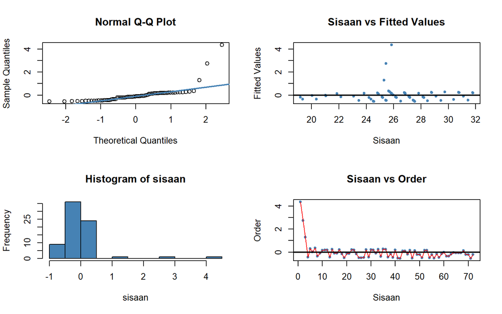

```r
#Sisaan dan fitted value
sisaan<- residuals(model)
fitValue<- predict(model)

#Diagnostik dengan eksploratif
par(mfrow = c(2,2))
qqnorm(sisaan)
qqline(sisaan, col = "steelblue", lwd = 2)
plot(fitValue, sisaan, col = "steelblue", pch = 20, xlab = "Sisaan", ylab = "Fitted Values", main = "Sisaan vs Fitted Values")
abline(a = 0, b = 0, lwd = 2)
hist(sisaan, col = "steelblue")
plot(seq(1,72,1), sisaan, col = "steelblue", pch = 20, xlab = "Sisaan", ylab = "Order", main = "Sisaan vs Order")
lines(seq(1,72,1), sisaan, col = "red")
abline(a = 0, b = 0, lwd = 2)
```

Dua plot di samping kiri digunakan untuk melihat apakah sisaan menyebar normal. Normal Q-Q Plot di atas menunjukkan bahwa sisaan cenderung menyebar normal, tetapi histogram dari sisaan tidak menunjukkan demikian. Selanjutnya, dua plot di samping kanan digunakan untuk melihat autokorelasi. Plot Sisaan vs *Fitted Value* dan Plot Sisaan vs *Order* menunjukkan adanya pola pada sisaan. Untuk lebih lanjut akan digunakan uji formal melihat normalitas sisaan dan plot ACF dan PACF untuk melihat apakah ada autokorelasi atau tidak.

```r
#Melihat Sisaan Menyebar Normal/Tidak
#H0: sisaan mengikuti sebaran normal
#H1: sisaan tidak mengikuti sebaran normal
shapiro.test(sisaan)
```

```
##
##  Shapiro-Wilk normality test
##
## data:  sisaan
## W = 0.54161, p-value = 1.2e-13
```

```r
ks.test(sisaan, "pnorm", mean=mean(sisaan), sd=sd(sisaan))
```

```
##
##  Asymptotic one-sample Kolmogorov-Smirnov test
##
## data:  sisaan
## D = 0.28453, p-value = 1.731e-05
## alternative hypothesis: two-sided
```

Berdasarkan uji formal Saphiro-Wilk dan Kolmogorov-Smirnov didapatkan nilai *p-value* < $\alpha$ (5%). Artinya, kurang cukup bukti untuk menyatakan sisaan berdistribusi normal.

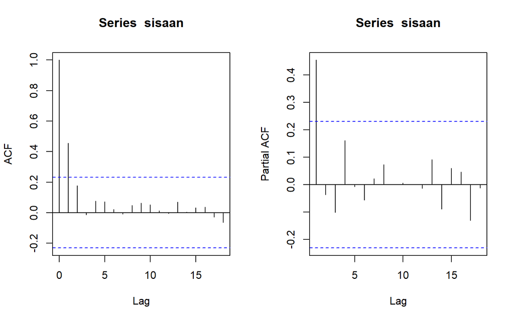

```r
#ACF dan PACF identifikasi autokorelasi
par(mfrow = c(1,2))
acf(sisaan)
pacf(sisaan)
```

Berdasarkan plot ACF dan PACF, terlihat ada beberapa yang melewati rentang batas dan signifikan. Namun, untuk lebih memastikan akan dilakukan uji formal dengan uji Durbin Watson.

```r
#Deteksi autokorelasi dengan uji-Durbin Watson
#H0: tidak ada autokorelasi
#H1: ada autokorelasi
dwtest(model)
```

```
##
##  Durbin-Watson test
##
## data:  model
## DW = 0.53581, p-value = 7.677e-15
## alternative hypothesis: true autocorrelation is greater than 0
```

Berdasarkan nilai *p-value* < 0.05 dapat disimpulkan bahwa tolak H0, cukup bukti mengatakan adanya autokorelasi. Oleh karena itu, diperlukan penangan autokorelasi. Penanganan yang akan digunakan menggunakan dua metode, yaitu Cochrane-Orcutt dan Hildret-Lu.

## Penanganan Autokorelasi

### Metode Cochrane-Orcutt

Penanganan metode Cochrane-Orcutt dapat dilakukan dengan bantuan packages Orcutt pada aplikasi `R` maupun secara manual. Berikut ini ditampilkan cara menggunakan bantuan `library` *packages* `Orcutt`.

```r
#Penanganan Autokorelasi Cochrane-Orcutt
modelCO<-cochrane.orcutt(model)
modelCO
```

```
## Cochrane-orcutt estimation for first order autocorrelation
##
## Call:
## lm(formula = AQI ~ o3 + CO, data = newdelhi)
##
##  number of interaction: 8
##  rho 0.461077
##
## Durbin-Watson statistic
## (original):    0.53581 , p-value: 7.677e-15
## (transformed): 2.71726 , p-value: 9.983e-01
##
##  coefficients:
## (Intercept)          o3          CO
##    4.946657    0.484000   -0.031304
```

```r
#Rho optimum
rho<- modelCO$rho
rho
```

```
## [1] 0.4610774
```

Selanjutnya akan dilakukan transformasi secara manual dengan syntax berikut ini.

```r
#Transformasi Manual
AQI.trans<- newdelhi$AQI[-1]-newdelhi$AQI[-72]*rho
CO.trans<- newdelhi$CO[-1]-newdelhi$CO[-72]*rho
o3.trans<- newdelhi$o3[-1]-newdelhi$o3[-72]*rho
modelCOmanual<- lm(AQI.trans~CO.trans+o3.trans)
summary(modelCOmanual)
```

```
##
## Call:
## lm(formula = AQI.trans ~ CO.trans + o3.trans)
##
## Residuals:
##      Min       1Q   Median       3Q      Max
## -0.93687 -0.23246  0.04246  0.18371  0.79204
##
## Coefficients:
##             Estimate Std. Error t value Pr(>|t|)
## (Intercept)  2.66587    2.25114   1.184    0.240
## CO.trans    -0.03130    0.02468  -1.268    0.209
## o3.trans     0.48400    0.01803  26.837   <2e-16 ***
## ---
## Signif. codes:  0 '***' 0.001 '**' 0.01 '*' 0.05 '.' 0.1 ' ' 1
##
## Residual standard error: 0.341 on 68 degrees of freedom
## Multiple R-squared:  0.9635, Adjusted R-squared:  0.9624
## F-statistic:   898 on 2 and 68 DF,  p-value: < 2.2e-16
```

```r
#Mencari Penduga Koefisien Regresi setelah Transformasi ke Persamaan Awal
b0bintang <- modelCOmanual$coefficients[1]
b0 <- b0bintang/(1-rho)
b1 <- modelCOmanual$coefficients[2]
b2 <- modelCOmanual$coefficients[3]
b0
```

```
## (Intercept)
##    4.946657
```

```r
b1
```

```
##    CO.trans
## -0.03130417
```

```r
b2
```

```
##  o3.trans
## 0.4839999
```

Hasil perhitungan koefisien regresi tersebut akan menghasilkan hasil yang sama dengan model yang dihasilkan menggunakan *packages*.

### Metode Hildreth-Lu

Penanganan kedua adalah menggunakan metode Hildreth-Lu. Metode ini akan mencari nilai SSE terkecil dan dapat dicari secara manual maupun menggunakan packages. Jika menggunakan packages, gunakan `library` *packages* `HORM`.

```r
#Penanganan Autokorelasi Hildreth lu
# Hildreth-Lu
hildreth.lu.func<- function(r, model){
  x1 <- model.matrix(model)[,2]
  x2 <- model.matrix(model)[,3]
  y <- model.response(model.frame(model))
  n <- length(y)
  t <- 2:n
  y <- y[t]-r*y[t-1]
  x1 <- x1[t]-r*x1[t-1]
  x2 <- x2[t]-r*x2[t-1]

  return(lm(y~x1+x2))
}

#Pencariab rho yang meminimumkan SSE
r <- c(seq(0.1,0.9, by= 0.1))
tab <- data.frame("rho" = r, "SSE" = sapply(r, function(i){deviance(hildreth.lu.func(i, model))}))
round(tab, 4)
```

```
##   rho     SSE
## 1 0.1 12.2384
## 2 0.2 10.1596
## 3 0.3  8.7585
## 4 0.4  8.0277
## 5 0.5  7.9550
## 6 0.6  8.5245
## 7 0.7  9.7209
## 8 0.8 11.5415
## 9 0.9 14.0117
```

Pertama-tama akan dicari di mana kira-kira $ρ$ yang menghasilkan SSE minimum. Pada hasil di atas terlihat $ρ$ minimum ketika 0.5. Namun, hasil tersebut masih kurang teliti sehingga akan dicari kembali $ρ$ yang lebih optimum dengan ketelitian yang lebih. Jika sebelumnya jarak antar $ρ$ yang dicari adalah 0.1, kali ini jarak antar $ρ$ adalah 0.001 dan dilakukan pada selang 0.4 sampai dengan 0.6 .

```r
#Rho optimal di sekitar 0.5
rOpt <- seq(0.4,0.6, by= 0.001)
tabOpt <- data.frame("rho" = rOpt, "SSE" = sapply(rOpt, function(i){deviance(hildreth.lu.func(i, model))}))
head(tabOpt[order(tabOpt$SSE),])
```

```
##      rho      SSE
## 62 0.461 7.905996
## 63 0.462 7.906024
## 61 0.460 7.906034
## 64 0.463 7.906116
## 60 0.459 7.906136
## 65 0.464 7.906273
```

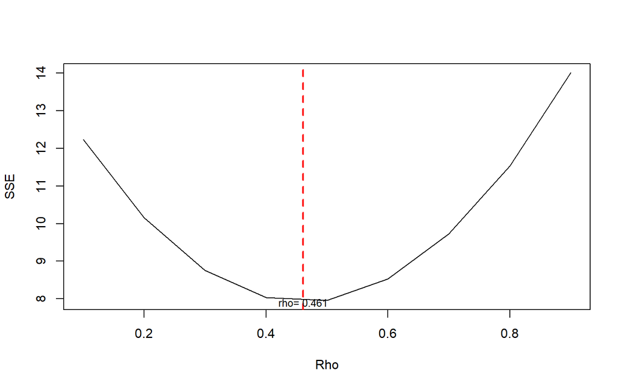

```r
#Grafik SSE optimum
par(mfrow = c(1,1))
plot(tab$SSE ~ tab$rho , type = "l", xlab = "Rho", ylab = "SSE")
abline(v = tabOpt[tabOpt$SSE==min(tabOpt$SSE),"rho"], lty = 2, col="red",lwd=2)
text(x= 0.461, y=7.905996, labels = "rho= 0.461", cex = 0.8)
```

Perhitungan yang dilakukan aplikasi `R` menunjukkan bahwa nilai $ρ$ optimum, yaitu saat SSE terkecil terdapat pada nilai $ρ=0.461$. Hal tersebut juga ditunjukkan pada plot. Selanjutnya, model dapat didapatkan dengan mengevaluasi nilai $ρ$ ke dalam fungsi `hildreth.lu.func`, serta dilanjutkan dengan pengujian autokorelasi dengan uji Durbin-Watson. Namun, setelah pengecekan tersebut tidak lupa koefisien regresi tersebut digunakan untuk transformasi balik. Persamaan hasil transformasi itulah yang menjadi persamaan sesungguhnya.

```r
#Model terbaik
modelHL <- hildreth.lu.func( 0.461, model)
summary(modelHL)
```

```
##
## Call:
## lm(formula = y ~ x1 + x2)
##
## Residuals:
##      Min       1Q   Median       3Q      Max
## -0.93679 -0.23246  0.04246  0.18373  0.79238
##
## Coefficients:
##             Estimate Std. Error t value Pr(>|t|)
## (Intercept)  2.66561    2.25129   1.184    0.241
## x1           0.48399    0.01803  26.839   <2e-16 ***
## x2          -0.03130    0.02468  -1.268    0.209
## ---
## Signif. codes:  0 '***' 0.001 '**' 0.01 '*' 0.05 '.' 0.1 ' ' 1
##
## Residual standard error: 0.341 on 68 degrees of freedom
## Multiple R-squared:  0.9635, Adjusted R-squared:  0.9625
## F-statistic: 898.2 on 2 and 68 DF,  p-value: < 2.2e-16
```

```r
#Transformasi Balik
cat("y = ", coefficients(modelHL)[1]/(1- 0.461), "+", coefficients(modelHL)[2],"x1","+",coefficients(modelHL)[3],"x2", sep = "")
```

```
## y = 4.945471+0.4839948x1+-0.03129671x2
```

Setelah dilakukan tranformasi balik, didapatkan model dengan metode Hildreth-Lu sebagai berikut.
$$y_i=4.945471+0.4839948x_1+-0.03129671x_2$$

```r
#Deteksi autokorelasi
dwtest(modelHL)
```

```
##
##  Durbin-Watson test
##
## data:  modelHL
## DW = 2.7171, p-value = 0.9983
## alternative hypothesis: true autocorrelation is greater than 0
```

Hasil uji Durbin-Watson juga menunjukkan bawah nilai DW sebesar $2.7171$. Hal tersebut didukung oleh *p-value* sebesar $0.9983$, di mana *p-value* <>$\alpha$=5%. Artinya tak tolak $H_0$ atau tidak cukup bukti menyatakan bahwa ada autokorelasi dalam data nilai AQI dengan metode Hildreth-Lu pada taraf nyata 5%.

Terakhir, akan dibandingkan nilai SSE dari ketiga metode (metode awal, metode Cochrane-Orcutt, dan Hildreth-Lu).

```r
#Perbandingan
sseModelawal <- anova(model)$`Sum Sq`[3]
sseModelCO <- anova(modelCOmanual)$`Sum Sq`[3]
sseModelHL <- anova(modelHL)$`Sum Sq`[3]
mseModelawal <- sseModelawal/length(newdelhi)
mseModelCO <- sseModelCO/length(newdelhi)
mseModelHL <- sseModelHL/length(newdelhi)
akurasi <- matrix(c(sseModelawal,sseModelCO,sseModelHL,
                    mseModelawal,mseModelCO,mseModelHL),nrow=2,ncol=3,byrow = T)
colnames(akurasi) <- c("Model Awal", "Model Cochrane-Orcutt", "Model Hildreth-Lu")
row.names(akurasi) <- c("SSE","MSE")
akurasi
```

```
##     Model Awal Model Cochrane-Orcutt Model Hildreth-Lu
## SSE  34.320749              7.905996          7.905996
## MSE   4.902964              1.129428          1.129428
```

# Simpulan

Autokorelasi yang terdapat pada data new delhi air quality terjadi akibat adanya korelasi di antara unsur penyusunnya. Indikator AQI yang erat hubungannya dengan O3 dan CO sangat rawan menjadi penyebab adanya autokorelasi. Adanya autokorelasi menyebabkan model regresi kurang baik karena akan meingkatkan galatnya. Autokorelasi dapat dideteksi secara eksploratif melalui plot sisaan, ACF, dan PACF, serta dengan uji formal Durbin-Watson. Namun, autokorelasi tersebut dapat ditangani dengan metode Cochrane-Orcutt dan Hildreth-Lu. Kedua metode menghasilkan nilai SSE yang sama, artinya keduanya baik untuk digunakan.